# Which variables carry the regime structure?

Cluster structure of the 14 CE scenarios, block by block — LEEDS_MODEL

Published

September 10, 2026

## The short version

Six variable blocks, 14 scenarios, long-term (t + 20) deviations in the joint `(Z1, Z2)` space. Every block carries structure better than a column-shuffled null. **But they do not carry the same amount of it, and the difference falls exactly along the macro / non-macro line.**

## 1 · How many groups does each block support?

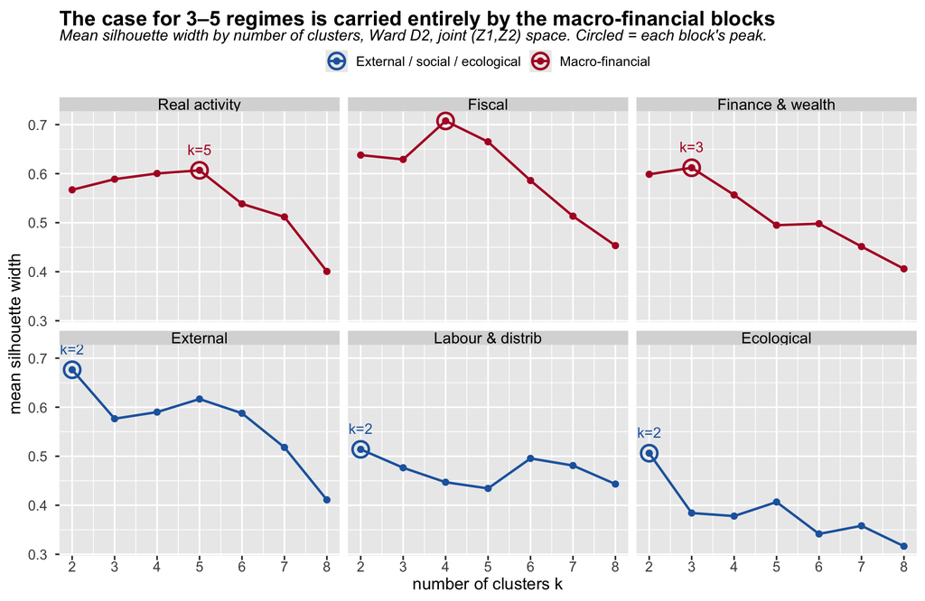

Figure 1

Real activity peaks at **k = 5**, Fiscal at **k = 4**, Finance & wealth at **k = 3**. Every non-macro block peaks at **k = 2**. The published five-regime taxonomy is visible in the data — but only through the macro-financial variables.

## 2 · Do different blocks find the *same* groups?

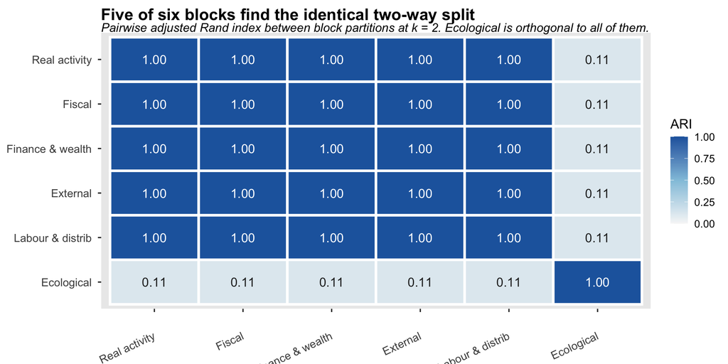

Figure 2

Real activity, Fiscal, Finance & wealth, External and Labour & distribution all return **`{1,3,4,6,7,8,9,11,12}` against `{2,5,10,13,14}`** — at ARI **1.00**, from five disjoint sets of variables. Ecological returns something else entirely (ARI 0.11): it splits `{everything}` from `{Sc5}`.

## 3 · The trees

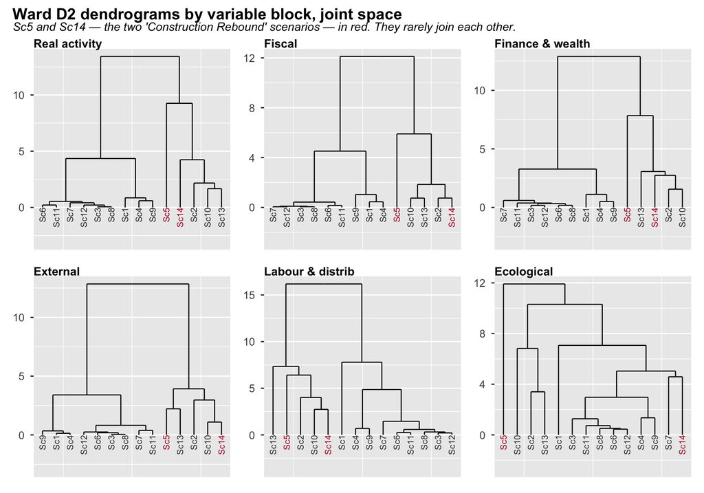

Figure 3

## 4 · The scenario map, and why Sc5 is not a regime member

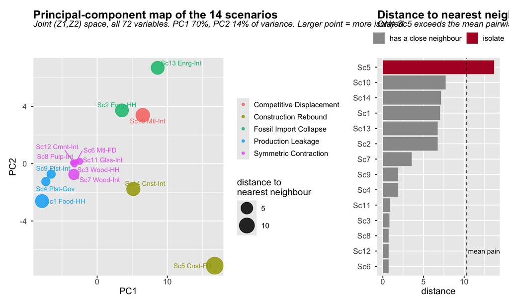

Figure 4

Table 1: Nearest neighbours in joint space. Mean pairwise distance = 10.25.

Nearest neighbours in joint space. Mean pairwise distance = 10.25.

| scenario | channel | nearest | d | 2nd nearest | d |
| --- | --- | --- | --- | --- | --- |
| Sc1 | Food-HH | Sc4 | 7.03 | Sc9 | 7.05 |
| Sc2 | Enrg-HH | Sc13 | 6.73 | Sc14 | 7.18 |
| Sc3 | Wood-HH | Sc8 | 0.81 | Sc12 | 1.22 |
| Sc4 | Plst-Gov | Sc9 | 1.89 | Sc8 | 5.39 |
| Sc5 | Cnst-FD | Sc14 | 13.70 | Sc10 | 16.17 |
| Sc6 | Mtl-FD | Sc12 | 0.72 | Sc8 | 0.81 |
| Sc7 | Wood-Int | Sc3 | 3.54 | Sc8 | 3.84 |
| Sc8 | Pulp-Int | Sc12 | 0.73 | Sc6 | 0.81 |
| Sc9 | Plst-Int | Sc4 | 1.89 | Sc8 | 4.05 |
| Sc10 | Mtl-Int | Sc2 | 7.73 | Sc14 | 7.93 |
| Sc11 | Glss-Int | Sc6 | 0.92 | Sc12 | 1.02 |
| Sc12 | Cmnt-Int | Sc6 | 0.72 | Sc8 | 0.73 |
| Sc13 | Enrg-Int | Sc2 | 6.73 | Sc10 | 10.29 |
| Sc14 | Cnst-Int | Sc2 | 7.18 | Sc10 | 7.93 |

So *Construction Rebound* groups two scenarios that share a **mechanism** — the investment multiplier — but not an **outcome profile**. Sc5 is an isolate; Sc14 belongs with the fossil and metals scenarios.

## 5 · Drop the two construction scenarios and three clusters fall out

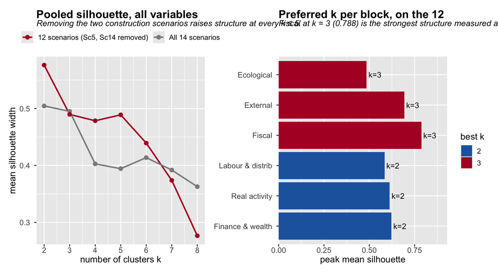

Figure 5

On the 12, `k = 3` returns **`{1,4,9}` · `{2,10,13}` · `{3,6,7,8,11,12}`** — Production Leakage, the divergence group, Symmetric Contraction — with no singletons. On all 14, `k = 3` instead returns `{sym nine}` · `{2,10,13,14}` · `{5}`: one of the three “clusters” is Sc5 alone.

**The five-regime taxonomy is three regimes plus two outliers.**

## 6 · ANOVA: which variables actually discriminate the regimes?

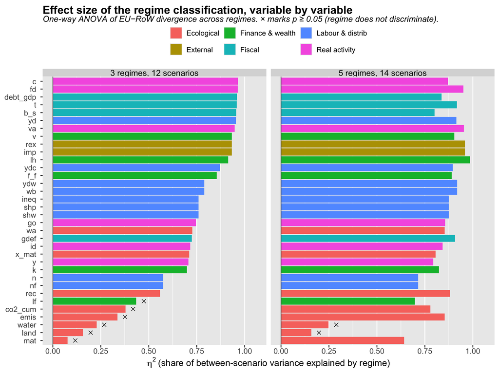

Figure 6

Read the right panel against the left. Under the three-regime taxonomy the discriminating variables are consumption (η² 0.965), final demand (0.964), debt/GDP (0.960), taxes (0.959) and public debt (0.957) — real activity and the fiscal block, all above 0.95.

**And the ecological variables collapse.** Emissions falls 0.853 → **0.336**, cumulative CO₂ 0.778 → **0.379**, materials 0.642 → **0.077** — none significant once Sc5 and Sc14 are out. Land (0.157) and water (0.228) never discriminated under either taxonomy.

**The current account is not in this figure, and that is a correction.** An earlier version of this report scored `cab` at η² = 0.137 and read it as a weak signal. It is not a weak signal: it is *structurally absent*. `Z1_cab = -Z2_cab` holds exactly, so the two regions’ percentage deviations are identical scenario by scenario and the divergence is zero — measured sd **1.9e-14** against sd 1.05 for the Z1 deviation itself. The number being scored was floating-point residue. `tb` and `g` cancel the same way (sd exactly 0) and were already excluded by the zero-variance guard; `cab` slipped through because its residue has variance ~4e-28, which is greater than zero. The guard is now a tolerance. `qmd/cross_border_analysis.qmd` had this right already and drops all three from divergence space.

## 7 · Does any of this survive the tariff-base correction?

Everything above is computed on the **`submitted`** arm — the specification as published, in which equation 5.4 assesses tariff revenue on a *real* import volume times the tariff rate and books it as nominal revenue, omitting the foreign price vector and the `(1 + tar)` divisor. Two corrected arms exist: `author_variant` (foreign market price, with the divisor) and `customs` (foreign pre-VAT price with the divisor — the destination principle, and the classically correct base).

Re-running sections 5 and 6 on all three arms:

|  | `submitted` | `author_variant` | `customs` |
| --- | --- | --- | --- |
| best k, 12 scenarios | 2 (0.576) | 2 (0.577) | 2 (0.578) |
| the k = 3 partition | `{1,4,9} {2,10,13} {3,6,7,8,11,12}` | identical | identical |
| ARI against `submitted` | — | **1.0000** | **1.0000** |

**The three-regime result is invariant to the correction.** So is the ANOVA, for 34 of 35 variables: mean |Δη²| between `submitted` and `customs` is **0.011**, and every ecological conclusion in section 6 moves by less than 0.004.

**The apparent exception was `cab`**, whose η² read 0.019 / 0.137 / 0.435 across the three arms — a range of 0.42. That is not tariff sensitivity. `cab`’s divergence is structurally zero (sd 1.9e-14), so all three numbers are η² computed on floating-point residue, and residue is not arm-invariant because it is not a quantity. With `cab` correctly excluded, **the ANOVA is invariant to the tariff correction across every variable it can legitimately score**: the largest remaining movement is `gdef` at |Δη²| = 0.041, which does not change its significance or its ranking.

Worth recording, because it refutes a plausible-sounding explanation: the two regions’ `cab` baselines rescale by *identical* factors (×1.1620 under `author_variant`, ×1.3580 under `customs`, Z1 and Z2 alike), so the differential-rescaling story does not apply here. `gdef` is the variable where the regional factors genuinely differ (×1.5978 vs ×1.6178, and ×2.3730 vs ×2.4198).